# Racially Polarized Voting Analysis–DRAFT

L Daly

3/26/2021

Testing racially polarized voting analyses in Los Angeles County.

# Why is Racially Polarized Voting (RPV) Important?

“Racially polarized voting is when all the minorities always vote for their preferred candidate and all the majorities always vote for their preferred candidate. If racially polarized voting exists, it is possible to gerrymander with brutal efficiency to ensure minorities have little or no representation in a four-seat legislature.” [(Public Mapping Project)](http://www.publicmapping.org/what-is-redistricting/redistricting-criteria-the-voting-rights-act)

RPV is how we determine if the preference of a race group is being suppressed. E.g. if all Latinos in a district tend to vote a certain way, but are grouped in a district in such a way that they are a minority of voters, they will never win their preferred outcome. So we first have to determine IF Latinos vote the same way, and then if they do, ensure they can have equitable representation.

### Guidelines of RPV Analysis

- It is recommended to use primary election data and/or non-partisan election data because general elections are so partisan, as are voting patterns by race/ethnicity, and RPV needs to separate out where voting choice is following partisan trends vs. race/ethnic bloc voting trends.
- It is also recommended to analyze multiple elections across multiple years in order to establish that there is a trend–not just one outlier election.

# Ecological Regression

I’m first going to run some RPV analyses using the ecological regression (ER) method.

Ecological regression is fine, but not as ideal as doing an ecological inference. I’ll try that later, but for now I’ll test a straightforward ER OLS:

*y = a + bx + e*

- Y is the dependent variable (% of the vote for something)
- A is the intercept—the point at which the regression line crosses the Y-axis
- B is the slope of the regression line
- X is the independent variable (% of voters of a specific race/ethnicity)
- E is an error term, indicating we are “somewhat uncertain”

First, load and prepare the data. This is data for the LA County Statement of Vote and voter turnout (from the Statewide Database).

```r
# load data --LA County SOV combined with Voter Turnout (Statewide Databse)
dat <- read.csv(here("Data/Racially Polarized Voting/la_county_turnout_test.csv"),
                stringsAsFactors  = FALSE,
                colClasses = c("srprec"="character"))
```

- I’m starting with SWDB data at the precinct level, and so for right now I can only do Latino and Asian analysis. Eventually I’ll try to use Block Group or Block CVAP estimates for other racial groups (i.e. Black eligible voters), but the SWDB doesn’t provide ready-made Block CVAP, and Block Group election outcomes seems a little coarse/too high geographic level.

## AD 59 (South LA)

I start with a small test of the primary election in CA State Assembly District 59 (South LA). This primary election was a contest between three democratic candidates: Reggie Jones-Sawyer, Marcello Villeda, and Efren Martinez.

I have the vote count for all precincts in Assembly District 59, and I’ve calculated the share of the vote that went to each candidate and the share of the vote for Latino voters.

### Sawyer-Jones

#### Latinx Voters

```r
# ER OLS

ad59_lm_jones = lm(jones_share ~ lat_share,
                   data = dat_59, na.action = na.omit)
summary(ad59_lm_jones)
```

```
##
## Call:
## lm(formula = jones_share ~ lat_share, data = dat_59, na.action = na.omit)
##
## Residuals:
##      Min       1Q   Median       3Q      Max
## -0.53576 -0.02268  0.00600  0.03864  0.12265
##
## Coefficients:
##             Estimate Std. Error t value Pr(>|t|)
## (Intercept)  0.66176    0.01876   35.27   <2e-16 ***
## lat_share   -0.50399    0.03286  -15.34   <2e-16 ***
## ---
## Signif. codes:  0 '***' 0.001 '**' 0.01 '*' 0.05 '.' 0.1 ' ' 1
##
## Residual standard error: 0.0767 on 130 degrees of freedom
##   (34 observations deleted due to missingness)
## Multiple R-squared:  0.644,  Adjusted R-squared:  0.6413
## F-statistic: 235.2 on 1 and 130 DF,  p-value: < 2.2e-16
```

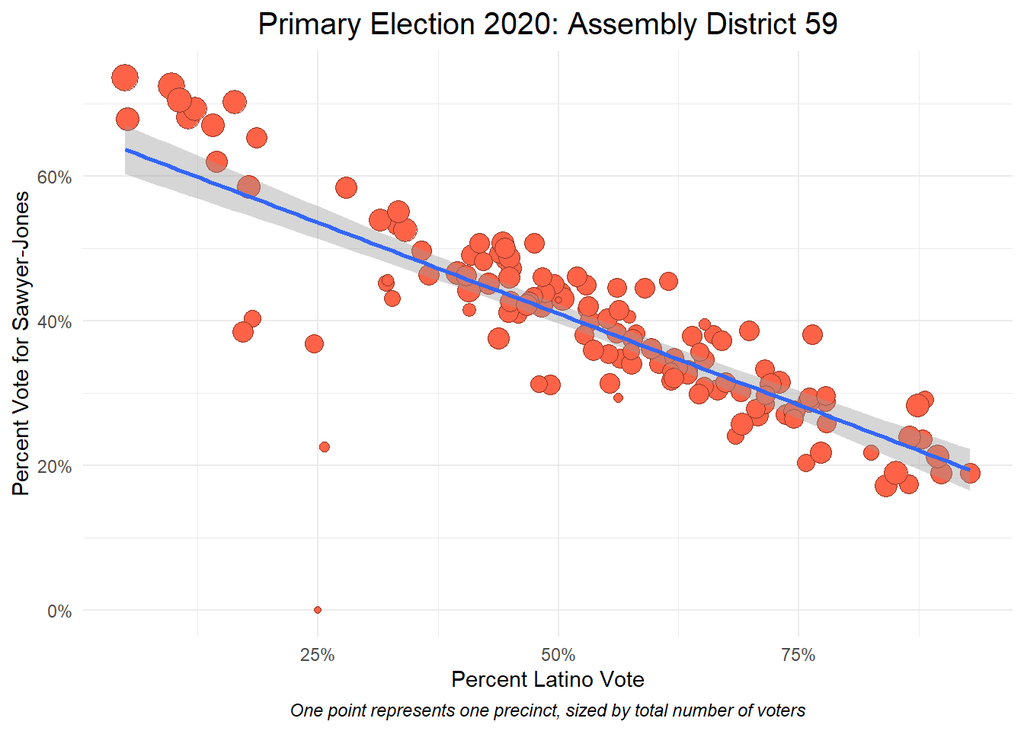

- **Graph and linear model show evidence of RPV for Latinx Voters in AD 59 rep. election.**

#### Asian Voters

I’m going to look at the trends for Asian voters as well, but in this district the population is likely too small to draw conclusions.

- While there are two precincts with % Asian voters > 20%, the mean Asian voter percentage is just under 3%. That is really small.

```r
# quick test with the asian share of the vote, but the population is likely too small to draw conclusions
ad59_lm_jones_asn = lm(jones_share ~ asn_share,
                   data = dat_59, na.action = na.omit)
summary(ad59_lm_jones_asn)
```

```
##
## Call:
## lm(formula = jones_share ~ asn_share, data = dat_59, na.action = na.omit)
##
## Residuals:
##      Min       1Q   Median       3Q      Max
## -0.23226 -0.09345 -0.00377  0.07637  0.32400
##
## Coefficients:
##             Estimate Std. Error t value Pr(>|t|)
## (Intercept)  0.41672    0.01418  29.387  < 2e-16 ***
## asn_share   -0.85314    0.32377  -2.635  0.00943 **
## ---
## Signif. codes:  0 '***' 0.001 '**' 0.01 '*' 0.05 '.' 0.1 ' ' 1
##
## Residual standard error: 0.1252 on 130 degrees of freedom
##   (34 observations deleted due to missingness)
## Multiple R-squared:  0.0507, Adjusted R-squared:  0.0434
## F-statistic: 6.944 on 1 and 130 DF,  p-value: 0.009435
```

- The coefficient is significant, but the R-squared is really low, indicating poor model fit.

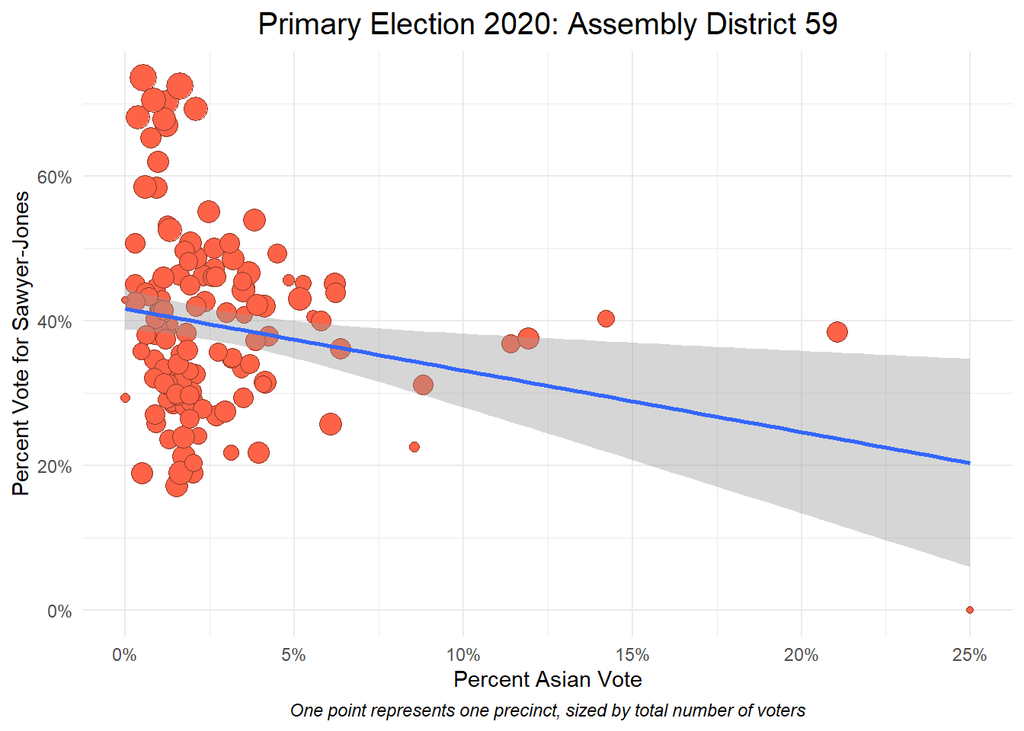

- **Asian voter population is too small in this district. No significant evidence for RPV.**

### Martinez

#### Latino Voters

```r
# ER OLS
ad59_lm_martinez = lm(martinez_share  ~ lat_share,
                   data = dat_59, na.action = na.omit)
summary(ad59_lm_martinez)
```

```
##
## Call:
## lm(formula = martinez_share ~ lat_share, data = dat_59, na.action = na.omit)
##
## Residuals:
##      Min       1Q   Median       3Q      Max
## -0.12575 -0.03356 -0.00380  0.02024  0.67050
##
## Coefficients:
##             Estimate Std. Error t value Pr(>|t|)
## (Intercept)  0.19463    0.01808   10.76   <2e-16 ***
## lat_share    0.53950    0.03167   17.03   <2e-16 ***
## ---
## Signif. codes:  0 '***' 0.001 '**' 0.01 '*' 0.05 '.' 0.1 ' ' 1
##
## Residual standard error: 0.07392 on 130 degrees of freedom
##   (34 observations deleted due to missingness)
## Multiple R-squared:  0.6906, Adjusted R-squared:  0.6882
## F-statistic: 290.2 on 1 and 130 DF,  p-value: < 2.2e-16
```

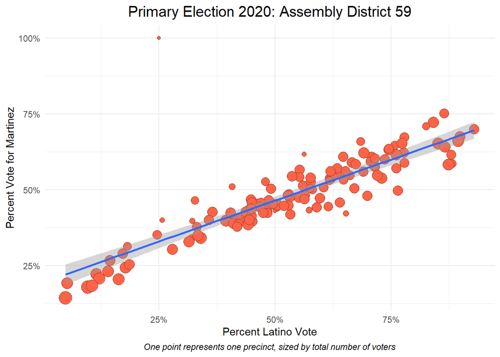

- **There is evidence of a Latinx voting bloc in AD 59. More elections needed for conclusive evidence.**

#### Asian Voters

```r
# ER OLS
ad59_lm_martinez_asn = lm(martinez_share  ~ asn_share ,
                   data = dat_59, na.action = na.omit)
summary(ad59_lm_martinez_asn)
```

```
##
## Call:
## lm(formula = martinez_share ~ asn_share, data = dat_59, na.action = na.omit)
##
## Residuals:
##      Min       1Q   Median       3Q      Max
## -0.33255 -0.07293 -0.00301  0.08855  0.45721
##
## Coefficients:
##             Estimate Std. Error t value Pr(>|t|)
## (Intercept)  0.47490    0.01501  31.641   <2e-16 ***
## asn_share    0.27158    0.34268   0.793    0.429
## ---
## Signif. codes:  0 '***' 0.001 '**' 0.01 '*' 0.05 '.' 0.1 ' ' 1
##
## Residual standard error: 0.1326 on 130 degrees of freedom
##   (34 observations deleted due to missingness)
## Multiple R-squared:  0.004808,   Adjusted R-squared:  -0.002847
## F-statistic: 0.6281 on 1 and 130 DF,  p-value: 0.4295
```

- Not statistically significant coefficient, R-squared very close to 0.

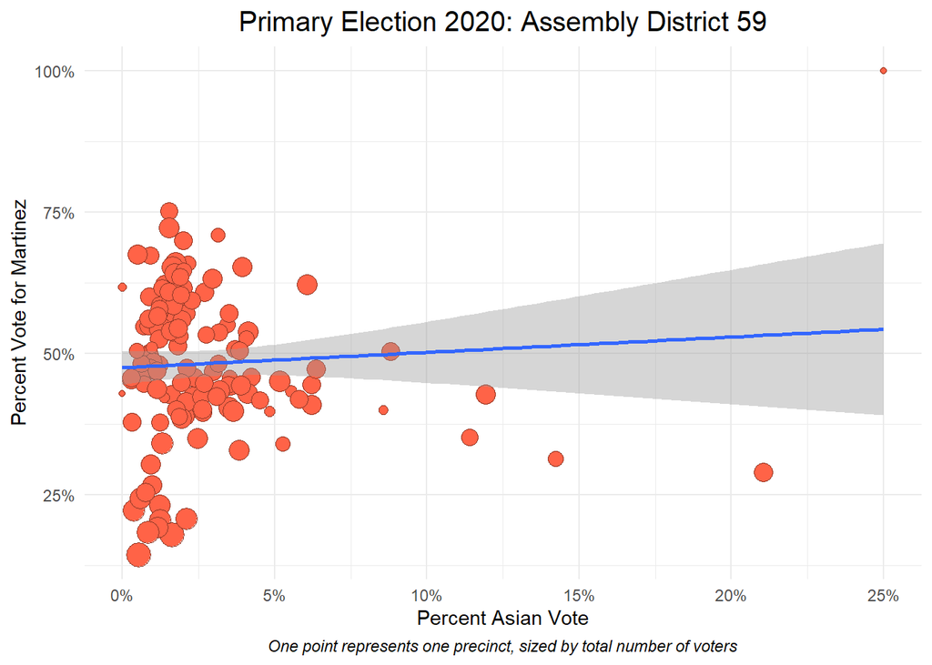

- **Asian voter population is too small in this district. No significant evidence for RPV.**

## Prop 13 (School Bond Measure)

#### AD 59: Latinx Voters

```r
# ols for ad 59

p13_lm_lat <- lm(yes13_share ~ lat_share, data = datp13, na.action = na.omit)

summary(p13_lm_lat)
```

```
##
## Call:
## lm(formula = yes13_share ~ lat_share, data = datp13, na.action = na.omit)
##
## Residuals:
##      Min       1Q   Median       3Q      Max
## -0.12933 -0.02907  0.00223  0.02552  0.33736
##
## Coefficients:
##             Estimate Std. Error t value Pr(>|t|)
## (Intercept)  0.66881    0.01420  47.083   <2e-16 ***
## lat_share   -0.02467    0.02488  -0.991    0.323
## ---
## Signif. codes:  0 '***' 0.001 '**' 0.01 '*' 0.05 '.' 0.1 ' ' 1
##
## Residual standard error: 0.05806 on 130 degrees of freedom
## Multiple R-squared:  0.007505,   Adjusted R-squared:  -0.0001293
## F-statistic: 0.9831 on 1 and 130 DF,  p-value: 0.3233
```

- Small negative coefficient that is not statistically significant. The plot shows no clear trend.

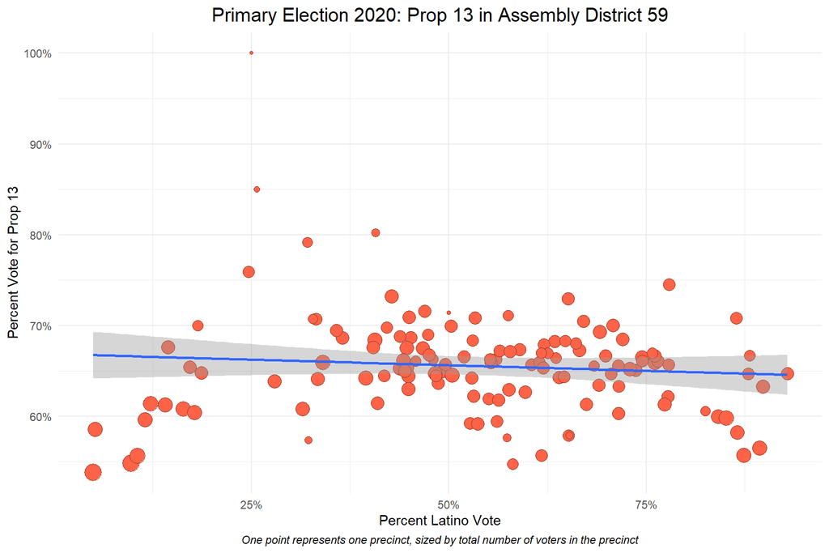

#### Asian Voters

```r
# ER OLS
p13_lm_asn = lm(yes13_share ~ asn_share,
                   data = datp13, na.action = na.omit)
summary(p13_lm_asn)
```

```
##
## Call:
## lm(formula = yes13_share ~ asn_share, data = datp13, na.action = na.omit)
##
## Residuals:
##       Min        1Q    Median        3Q       Max
## -0.147715 -0.031029  0.004215  0.023914  0.167010
##
## Coefficients:
##             Estimate Std. Error t value Pr(>|t|)
## (Intercept) 0.633269   0.005842  108.40  < 2e-16 ***
## asn_share   0.798882   0.133377    5.99 1.93e-08 ***
## ---
## Signif. codes:  0 '***' 0.001 '**' 0.01 '*' 0.05 '.' 0.1 ' ' 1
##
## Residual standard error: 0.0516 on 130 degrees of freedom
## Multiple R-squared:  0.2163, Adjusted R-squared:  0.2103
## F-statistic: 35.88 on 1 and 130 DF,  p-value: 1.931e-08
```

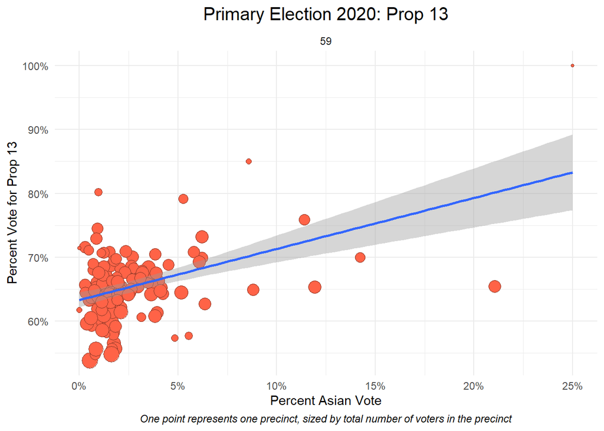

## Conclusion

In AD 59, we see evidence of RPV among Latinx voters in the Assembly District representative election. The Prop 13 contest does not reveal a Latinx voting bloc–we need to analyze more elections, and more racial/ethnic groups.

Next steps: Convert CVAP data into blocks, or keep as block groups, and convert election data to blocks/block groups. Conduct same analysis with Black CVAP data, white CVAP data, and also test out ecological inference tools.

# Sources include:

1. Presentation: Defining Racially Polarized Voting (Barreto, 2013)
2. A Summary of Voting Patterns in Los Angeles County (Baretto, 2011)
3. Report of J . Morgan Kousser for Luna v. County of Kern (Kousser, 2017)
4. eiCompare: Comparing Ecological Inference Estimates across Ei and EI:RxC (Collingwood et al., 2016)
5. [Public Mapping Project](http://www.publicmapping.org/what-is-redistricting/redistricting-criteria-the-voting-rights-act)
6. Statewide Database